# index

## Name: Patrick Mugisha

###### Source of data: Tableau.com

#### K-State Honor Code: "On my honor, as a student, I have neither given nor received unauthorized aid on this academic work."

```python
import pandas as pd
import numpy as np

%matplotlib inline
import matplotlib.pyplot as plt

import seaborn as sns

from scipy import stats

pd.set_option('display.max_columns', 500)
```

## Connect to the Data

```python
df=pd.read_excel('data/SuperstoreSales.xlsx')
df.head(2)
```

|  | Order ID | Order Date | Order Priority | Order Quantity | Sales | Discount | Ship Mode | Profit | Unit Price | Shipping Cost | Customer Name | Customer State | Zip Code | Region | Customer Segment | Product Category | Product Sub-Category | Product Name | Product Container | Product Base Margin | Ship Date |
| --- | --- | --- | --- | --- | --- | --- | --- | --- | --- | --- | --- | --- | --- | --- | --- | --- | --- | --- | --- | --- | --- |
| 0 | 3 | 2010-08-26 | Low | 6 | 261.54 | 0.04 | Regular Air | -213.25 | 38.94 | 35.00 | Muhammed MacIntyre | New Jersey | 7514 | East | Small Business | Office Supplies | Storage & Organization | Eldon Base for stackable storage shelf, platinum | Large Box | 0.80 | 2010-09-02 |
| 1 | 6 | 2012-01-03 | Not Specified | 2 | 6.93 | 0.01 | Regular Air | -4.64 | 2.08 | 2.56 | Ruben Dartt | New York | 10457 | East | Corporate | Office Supplies | Scissors, Rulers and Trimmers | Kleencut® Forged Office Shears by Acme United ... | Small Pack | 0.55 | 2012-01-04 |

```python
# check column names, number of observations, data type
df.info()
```

```
<class 'pandas.core.frame.DataFrame'>
RangeIndex: 8399 entries, 0 to 8398
Data columns (total 21 columns):
 #   Column                Non-Null Count  Dtype
---  ------                --------------  -----
 0   Order ID              8399 non-null   int64
 1   Order Date            8399 non-null   datetime64[ns]
 2   Order Priority        8399 non-null   object
 3   Order Quantity        8399 non-null   int64
 4   Sales                 8399 non-null   float64
 5   Discount              8399 non-null   float64
 6   Ship Mode             8399 non-null   object
 7   Profit                8399 non-null   float64
 8   Unit Price            8399 non-null   float64
 9   Shipping Cost         8399 non-null   float64
 10  Customer Name         8399 non-null   object
 11  Customer State        8399 non-null   object
 12  Zip Code              8399 non-null   int64
 13  Region                8399 non-null   object
 14  Customer Segment      8399 non-null   object
 15  Product Category      8399 non-null   object
 16  Product Sub-Category  8399 non-null   object
 17  Product Name          8399 non-null   object
 18  Product Container     8399 non-null   object
 19  Product Base Margin   8399 non-null   float64
 20  Ship Date             8399 non-null   datetime64[ns]
dtypes: datetime64[ns](2), float64(6), int64(3), object(10)
memory usage: 1.3+ MB
```

## Rename column names

- Remove extra spaces
- Lowercase names

```python
df.columns=df.columns.str.replace(' ', '')
df.columns=df.columns.str.lower()
df.head(2)
```

|  | orderid | orderdate | orderpriority | orderquantity | sales | discount | shipmode | profit | unitprice | shippingcost | customername | customerstate | zipcode | region | customersegment | productcategory | productsub-category | productname | productcontainer | productbasemargin | shipdate |
| --- | --- | --- | --- | --- | --- | --- | --- | --- | --- | --- | --- | --- | --- | --- | --- | --- | --- | --- | --- | --- | --- |
| 0 | 3 | 2010-08-26 | Low | 6 | 261.54 | 0.04 | Regular Air | -213.25 | 38.94 | 35.00 | Muhammed MacIntyre | New Jersey | 7514 | East | Small Business | Office Supplies | Storage & Organization | Eldon Base for stackable storage shelf, platinum | Large Box | 0.80 | 2010-09-02 |
| 1 | 6 | 2012-01-03 | Not Specified | 2 | 6.93 | 0.01 | Regular Air | -4.64 | 2.08 | 2.56 | Ruben Dartt | New York | 10457 | East | Corporate | Office Supplies | Scissors, Rulers and Trimmers | Kleencut® Forged Office Shears by Acme United ... | Small Pack | 0.55 | 2012-01-04 |

```python
df.columns
```

```
Index(['orderid', 'orderdate', 'orderpriority', 'orderquantity', 'sales',
       'discount', 'shipmode', 'profit', 'unitprice', 'shippingcost',
       'customername', 'customerstate', 'zipcode', 'region', 'customersegment',
       'productcategory', 'productsub-category', 'productname',
       'productcontainer', 'productbasemargin', 'shipdate'],
      dtype='object')
```

## Inspect data

```python
# check missing values

df.isnull().sum()
```

```
orderid                0
orderdate              0
orderpriority          0
orderquantity          0
sales                  0
discount               0
shipmode               0
profit                 0
unitprice              0
shippingcost           0
customername           0
customerstate          0
zipcode                0
region                 0
customersegment        0
productcategory        0
productsub-category    0
productname            0
productcontainer       0
productbasemargin      0
shipdate               0
dtype: int64
```

```python
# summary statistics

df.describe()
```

|  | orderid | orderquantity | sales | discount | profit | unitprice | shippingcost | zipcode | productbasemargin |
| --- | --- | --- | --- | --- | --- | --- | --- | --- | --- |
| count | 8399.000000 | 8399.000000 | 8399.000000 | 8399.000000 | 8399.000000 | 8399.000000 | 8399.000000 | 8399.000000 | 8399.000000 |
| mean | 29965.179783 | 25.575426 | 1774.860490 | 0.049664 | 181.401194 | 89.310426 | 12.856427 | 48256.097631 | 0.512886 |
| std | 17260.883447 | 14.482837 | 3585.107345 | 0.031826 | 1224.670845 | 290.361311 | 17.318257 | 30689.098271 | 0.135991 |
| min | 3.000000 | 1.000000 | 2.240000 | 0.000000 | -16253.680000 | 0.990000 | 0.490000 | 501.000000 | 0.350000 |
| 25% | 15011.500000 | 13.000000 | 143.035000 | 0.020000 | -82.764250 | 6.480000 | 3.300000 | 21794.000000 | 0.380000 |
| 50% | 29857.000000 | 26.000000 | 449.420000 | 0.050000 | -1.490000 | 20.990000 | 6.070000 | 43317.000000 | 0.520000 |
| 75% | 44596.000000 | 38.000000 | 1706.285000 | 0.080000 | 166.712250 | 85.990000 | 13.990000 | 81221.000000 | 0.590000 |
| max | 59973.000000 | 50.000000 | 89061.050000 | 0.250000 | 27220.690000 | 6783.020000 | 164.730000 | 99403.000000 | 0.850000 |

## Indexing

```python
# index is like primary key in database (unique number assigned to each observation)
# check index column

df.index
```

```
RangeIndex(start=0, stop=8399, step=1)
```

```python
# then set datetime [date] column as index (primary key). This is for time series analysis below.
# orderdate

df=df.set_index('orderdate')
df.head(2)
```

| orderdate | orderid | orderpriority | orderquantity | sales | discount | shipmode | profit | unitprice | shippingcost | customername | customerstate | zipcode | region | customersegment | productcategory | productsub-category | productname | productcontainer | productbasemargin | shipdate |
| --- | --- | --- | --- | --- | --- | --- | --- | --- | --- | --- | --- | --- | --- | --- | --- | --- | --- | --- | --- | --- |
| 2010-08-26 | 3 | Low | 6 | 261.54 | 0.04 | Regular Air | -213.25 | 38.94 | 35.00 | Muhammed MacIntyre | New Jersey | 7514 | East | Small Business | Office Supplies | Storage & Organization | Eldon Base for stackable storage shelf, platinum | Large Box | 0.80 | 2010-09-02 |
| 2012-01-03 | 6 | Not Specified | 2 | 6.93 | 0.01 | Regular Air | -4.64 | 2.08 | 2.56 | Ruben Dartt | New York | 10457 | East | Corporate | Office Supplies | Scissors, Rulers and Trimmers | Kleencut® Forged Office Shears by Acme United ... | Small Pack | 0.55 | 2012-01-04 |

- The table above shows that column "orderdate" was set as the index which will make time analysis possible to do

## Summary Questions

### What is the total sales (sum())?

```python
df['sales'].sum()
```

```
14907053.254
```

### What is the total profit?

```python
df['profit'].sum()
```

```
1523588.6295
```

## Time series (seasonality)

### Do you observe any seasonality in the sales volume?

- it appears there is seasonality in the trend of sales volume

```python
month=df.resample('M').size()
month.head()
```

```
orderdate
2008-11-30    141
2008-12-31    182
2009-01-31    153
2009-02-28    186
2009-03-31    177
Freq: M, dtype: int64
```

```python
monthsum=df.resample('M').sum()
monthsum.head()
```

| orderdate | orderid | orderquantity | sales | discount | profit | unitprice | shippingcost | zipcode | productbasemargin |
| --- | --- | --- | --- | --- | --- | --- | --- | --- | --- |
| 2008-11-30 | 3861057 | 3352 | 303089.5465 | 6.76 | 23256.1785 | 19202.58 | 1946.95 | 7224279 | 73.16 |
| 2008-12-31 | 5915189 | 4814 | 427854.4250 | 9.11 | 45477.2050 | 20256.07 | 2848.97 | 9539552 | 92.05 |
| 2009-01-31 | 4709069 | 3581 | 295281.2650 | 7.53 | -6656.1085 | 23614.82 | 2531.44 | 6451957 | 81.04 |
| 2009-02-28 | 5500425 | 4705 | 448367.6080 | 9.37 | 63989.8160 | 28162.80 | 2296.74 | 8956195 | 94.45 |
| 2009-03-31 | 5152652 | 4738 | 297821.1905 | 9.20 | 25337.5000 | 11748.30 | 2212.40 | 9839537 | 90.88 |

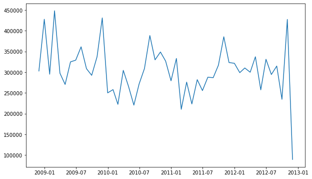

```python
plt.figure(figsize=[10,6])
plt.plot(monthsum['sales'])
```

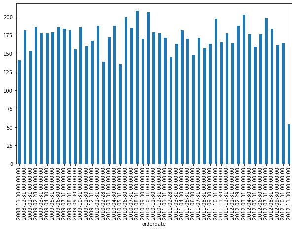

```python
plt.figure(figsize=[10,6])
df.resample('M').size().plot(kind='bar')
```

- The bar graph above visualizes the number of sales made each month with clear end of the month dates.

```python
#which month with the highest sales? October is that month (make this a mark down)

df.groupby(df.index.strftime('%B'))['sales'].size().sort_values(ascending=False)
```

```
orderdate
October      753
July         738
August       731
April        723
March        715
June         709
December     703
November     699
January      676
February     658
September    650
May          644
Name: sales, dtype: int64
```

- The table above shows the months in full name instead of dates, and shows the number of sales made that month with October being the month with highest number of sales.

```python
#Which month has the highest profit?

df.groupby(df.index.strftime('%B'))['profit'].sum().sort_values(ascending=False)
```

```
orderdate
August       167858.6745
November     155983.4200
September    147600.0670
October      137874.7760
February     125970.5260
May          124034.5890
April        121924.6240
March        117642.5065
December     113894.4390
July         108811.6365
January      104597.5425
June          97395.8285
Name: profit, dtype: float64
```

- The table above shows the total profit made each month in decreasing order, and August is the month with the most profit made.

### Do you observe any seasonality in the shipping cost?

- It appears there is seasonality in the trend of shipping cost.

```python
df.groupby(df.index.strftime('%B'))['shippingcost'].sum().sort_values(ascending=False)
```

```
orderdate
October      10321.00
November     10005.58
July          9669.23
December      9606.14
June          9344.89
January       8848.27
March         8776.34
September     8528.43
August        8517.75
April         8400.05
February      8288.41
May           7675.04
Name: shippingcost, dtype: float64
```

- The table above shows the total shipping cost from each month in decreasing order, it starts with October which has the highest total shipping cost

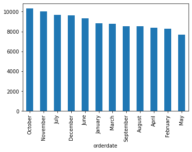

```python
df.groupby(df.index.strftime('%B'))['shippingcost'].sum().sort_values(ascending=False).plot(kind='bar')
```

- The bar graph above visualises individual months and the total amount of shipping cost in those months.

## Detailed Questions

### What is the sales total in each product category? Which product category is doing well?

```python
df.groupby('productcategory')['sales'].sum().sort_values(ascending=False)
```

```
productcategory
Technology         5987571.402
Furniture          5119254.482
Office Supplies    3800227.370
Name: sales, dtype: float64
```

- The table above shows total sales in each product category, and technology is doing well.

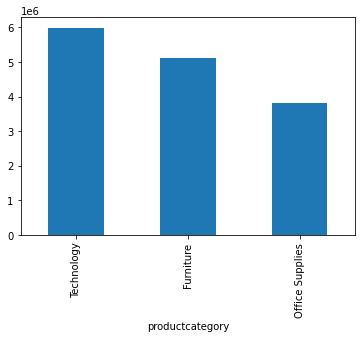

```python
df.groupby('productcategory')['sales'].sum().sort_values(ascending=False).plot(kind='bar')
```

- The bar plot above visualizes each product category and their total sales. Technolgy is doing well in terms of sales while office supplies come in last.

### What are top two categories in terms of profit?

```python
df.groupby('productcategory')['profit'].sum().sort_values(ascending=False).head(2)
```

```
productcategory
Technology         855437.2250
Office Supplies    515776.6045
Name: profit, dtype: float64
```

- The table above shows the total profit made in each product category. The top 2 categories in terms of profit are Technology and Office Supplies.

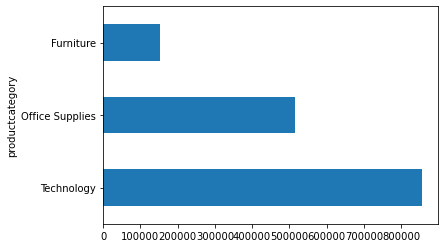

```python
df.groupby('productcategory')['profit'].sum().sort_values(ascending=False).head().plot(kind='barh')
```

- The bar plot above is a visual representation of profit made from sales in each product category.

### Which region is profitable compared to other regions? Any region experiencing financial losses? (Include productcategory in this analysis)

```python
df.groupby('region')['profit'].sum().sort_values(ascending=False).head()
```

```
region
South      505678.7515
West       422868.1505
East       297802.5185
Central    297239.2090
Name: profit, dtype: float64
```

- The south is the most profitable of all four regions.

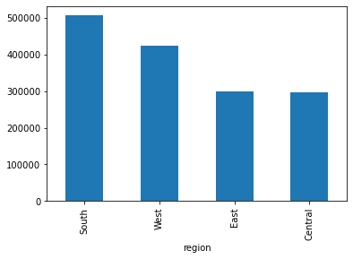

```python
df.groupby('region')['profit'].sum().sort_values(ascending=False).head().plot(kind='bar')
```

- The bar plot above visualizes sum of profit made in each of the four regions.

```python
df.pivot_table(index="region", columns="productcategory", values="profit", \
               aggfunc='sum', fill_value=0, margins=True)
```

| productcategory region | Furniture | Office Supplies | Technology | All |
| --- | --- | --- | --- | --- |
| Central | 44509.69 | 121977.2900 | 130752.229 | 2.972392e+05 |
| East | -12721.46 | 107470.5935 | 203053.385 | 2.978025e+05 |
| South | 62901.90 | 140659.2615 | 302117.590 | 5.056788e+05 |
| West | 57684.67 | 145669.4595 | 219514.021 | 4.228682e+05 |
| All | 152374.80 | 515776.6045 | 855437.225 | 1.523589e+06 |

- The table above shows the total profit made from each product category in every region and it seems to be a financial loss in the furniture product category from the East region.

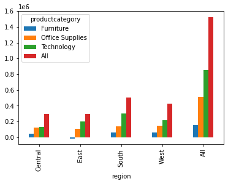

```python
df.pivot_table(index="region", columns="productcategory", values="profit", \
               aggfunc='sum', fill_value=0, margins=True).plot(kind='bar')
```

- The graph above visualizes the profits made in each product category in every region, it also shows that the east region had a loss on the furniture product category.

### Which state in the East is least profitable? Include Product Category in your analysis.

```python
eaststates = df.loc[df['region'] == 'East']
eaststates.groupby('productcategory')['profit'].sum()
eaststates.head(2)
```

| orderdate | orderid | orderpriority | orderquantity | sales | discount | shipmode | profit | unitprice | shippingcost | customername | customerstate | zipcode | region | customersegment | productcategory | productsub-category | productname | productcontainer | productbasemargin | shipdate |
| --- | --- | --- | --- | --- | --- | --- | --- | --- | --- | --- | --- | --- | --- | --- | --- | --- | --- | --- | --- | --- |
| 2010-08-26 | 3 | Low | 6 | 261.54 | 0.04 | Regular Air | -213.25 | 38.94 | 35.00 | Muhammed MacIntyre | New Jersey | 7514 | East | Small Business | Office Supplies | Storage & Organization | Eldon Base for stackable storage shelf, platinum | Large Box | 0.80 | 2010-09-02 |
| 2012-01-03 | 6 | Not Specified | 2 | 6.93 | 0.01 | Regular Air | -4.64 | 2.08 | 2.56 | Ruben Dartt | New York | 10457 | East | Corporate | Office Supplies | Scissors, Rulers and Trimmers | Kleencut® Forged Office Shears by Acme United ... | Small Pack | 0.55 | 2012-01-04 |

- The table above displays everything happening in the east region states.

```python
eaststates.pivot_table(index="customerstate", columns="productcategory", values="profit", \
               aggfunc='sum', fill_value=0, margins=True)
```

| productcategory customerstate | Furniture | Office Supplies | Technology | All |
| --- | --- | --- | --- | --- |
| Connecticut | -12852.13 | 20425.2045 | 36178.566 | 43751.6405 |
| Delaware | 938.99 | 5662.7815 | 29740.743 | 36342.5145 |
| Mass | -5651.18 | 41313.6870 | 33954.677 | 69617.1840 |
| New Jersey | -18171.95 | 14495.9140 | 39667.960 | 35991.9240 |
| New York | 23014.81 | 25573.0065 | 63511.439 | 112099.2555 |
| All | -12721.46 | 107470.5935 | 203053.385 | 297802.5185 |

- The table above contains some really important information from the east region: (1) New York is the best performing state in the east in terms of profit. (2) New Jersey is the worst perfoming state in the east in terms of profit. (3) Furniture is the only product category that has experienced losses in the east region, it reported losses in Connecticut, Massachusetts and New Jersey. (4) Furniture is having an overall loss in the east region.

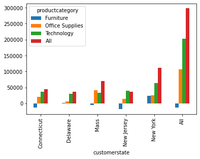

```python
eaststates.pivot_table(index="customerstate", columns="productcategory", values="profit", \
               aggfunc='sum', fill_value=0, margins=True).plot(kind='bar')
```

- The bar graph above shows the profit made from each product category in each state from the east region. Furniture is having an overall loss in profits.

### Nebraska

#### For the State of Nebraska, which year is least profitable? which product is least profitable?

```python
nebraska = df.loc[df['customerstate'] == 'Nebraska']
nebyear=nebraska.resample('Y')['profit'].sum().sort_values(ascending=False)
nebyear.head()
```

```
orderdate
2009-12-31    18355.1030
2012-12-31    15597.6875
2011-12-31    12363.0425
2010-12-31    12314.2330
2008-12-31     -363.9200
Name: profit, dtype: float64
```

- The table above shows the profits made in Nebraska every year. In 2008 Nebraska reported a loss, therefore making it the least profitable year.

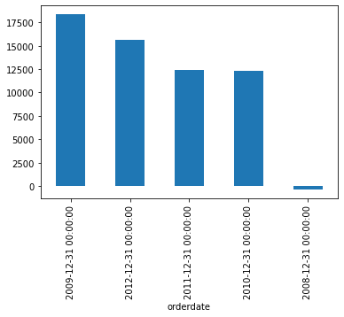

```python
nebyear=nebraska.resample('Y')['profit'].sum().sort_values(ascending=False).plot(kind='bar')
```

- The bar graph above shows visual representation of profits recorded every year.

```python
nebraska.groupby('productsub-category')['profit'].sum().sort_values(ascending=False)
```

```
productsub-category
Chairs & Chairmats                20138.890
Copiers and Fax                   17546.489
Binders and Binder Accessories     8787.901
Telephones and Communication       7394.336
Appliances                         5684.610
Office Furnishings                 4007.010
Paper                              3140.810
Envelopes                           753.590
Pens & Art Supplies                 707.730
Labels                              422.790
Computer Peripherals                 57.860
Rubber Bands                         16.850
Scissors, Rulers and Trimmers      -266.860
Storage & Organization             -631.050
Bookcases                         -1086.110
Office Machines                   -3146.690
Tables                            -5262.010
Name: profit, dtype: float64
```

- The table above shows the profit made from each product sub-category in the state of Nebraska. It looks like Tables is the least profitable product in Nebraska.

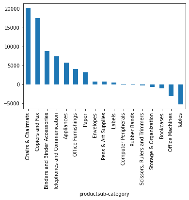

```python
nebraska.groupby('productsub-category')['profit'].sum().sort_values(ascending=False).plot(kind='bar')
```

- The graph above visualizes the profits made from each product sub-category in Nebraska.

#### Which part of Nebraska is profitable?

```python
nebraska = df.loc[df['customerstate'] == 'Nebraska']
nebraska.groupby('zipcode')['profit'].sum().sort_values(ascending=False)
```

```
zipcode
68770    19498.4820
68717    12265.1240
69367    10809.8590
68001     7771.4990
68155     7049.8825
69141     1302.5270
69358      185.5075
68016     -616.7350
Name: profit, dtype: float64
```

- The table above shows exactly the zipcodes in nebraska and how much profit they generate. only one zipcode in nebraska is generating a loss.

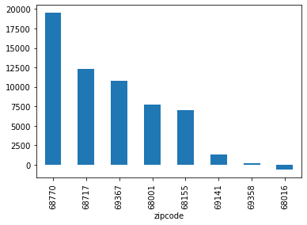

```python
nebraska.groupby('zipcode')['profit'].sum().sort_values(ascending=False).plot(kind='bar')
```

- The table above visualizes the profits made in every zipcode in nebraska. zipcode:68016 is generating a loss.

### Overall, what kinds of furniture are not profitable?

```python
furn = df.loc[df['productcategory'] == 'Furniture']
furn.groupby('productsub-category')['profit'].sum().sort_values(ascending=False)
```

```
productsub-category
Chairs & Chairmats    149938.23
Office Furnishings     96878.40
Bookcases             -33170.68
Tables                -61271.15
Name: profit, dtype: float64
```

- The table above shows overall profit from each type of furniture in the product sub-category. Bookcases and Tables are not making any profit.

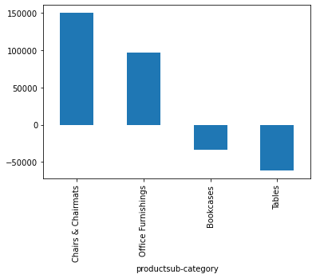

```python
furn.groupby('productsub-category')['profit'].sum().sort_values(ascending=False).plot(kind='bar')
```

- The bar graph above shows the overall profit made from each kind of furniture. There was 2 recorded losses from Bookcases and Tables.

### Overall, what kinds of office supplies are most profitable? What kinds of office supplies need to be improved in terms of sales and profits?

```python
furnoff = df.loc[df['productcategory'] == 'Office Supplies']
furnoff.groupby('productsub-category')['profit'].sum().sort_values(ascending=False)
```

```
productsub-category
Binders and Binder Accessories    307174.1845
Appliances                         98023.0800
Envelopes                          48711.0800
Paper                              45987.2000
Labels                             13689.1500
Pens & Art Supplies                 7551.8100
Storage & Organization              2516.9400
Rubber Bands                         -77.5900
Scissors, Rulers and Trimmers      -7799.2500
Name: profit, dtype: float64
```

- The most profitable office supplies are Binders and Binder Accessories. Office supplies that need to be improved in terms of profit are Rubber Bands, Scissors, Rulers and Trimmers

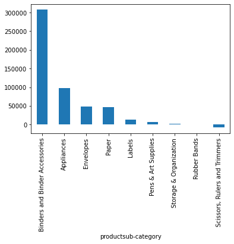

```python
furnoff.groupby('productsub-category')['profit'].sum().sort_values(ascending=False).plot(kind='bar')
```

- The bar graph above shows overall office supplies in terms of profit. 2 product sub-categories are reporting a loss.

```python
furnoff.groupby('productsub-category')['sales'].sum().sort_values(ascending=False)
```

```
productsub-category
Storage & Organization            1099774.36
Binders and Binder Accessories    1024521.85
Appliances                         747333.01
Paper                              449496.47
Envelopes                          176298.06
Pens & Art Supplies                167525.03
Scissors, Rulers and Trimmers       80996.31
Labels                              39042.35
Rubber Bands                        15239.93
Name: sales, dtype: float64
```

### Overall, what kinds of technology are profitable?

```python
tech = df.loc[df['productcategory'] == 'Technology']
tech.groupby('productsub-category')['profit'].sum().sort_values(ascending=False)
```

```
productsub-category
Telephones and Communication    316951.641
Office Machines                 276590.340
Copiers and Fax                 167361.464
Computer Peripherals             94533.780
Name: profit, dtype: float64
```

- All the technology product sub-category items are profitable.

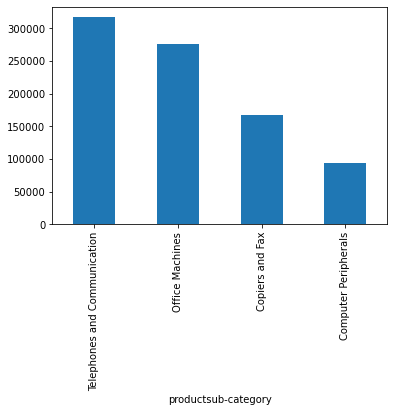

```python
tech.groupby('productsub-category')['profit'].sum().sort_values(ascending=False).plot(kind='bar')
```

- The Technology product sub-categorys are all profitable with Telephones and Communication being the most profitable and Computer Peripherals being the least profitable.

### Is there any relationship (or correlation) between “profits” and “sales”? Show a trend line

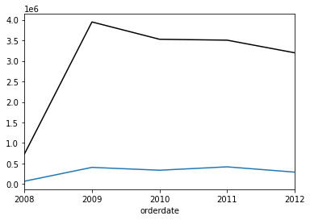

```python
df.resample('Y')['profit'].sum().plot()
df.resample('Y')['sales'].sum().plot(color='k')
```

### Overall, which year is least profitable?

- Ignore year 2008 since it has only two months in the data

```python
year=df.resample('Y')['profit'].sum().sort_values(ascending=False)
year
```

```
orderdate
2011-12-31    419755.3845
2009-12-31    406718.5260
2010-12-31    337239.4165
2012-12-31    291141.9190
2008-12-31     68733.3835
Name: profit, dtype: float64
```

```python
year=df.resample('Y')['profit'].sum().sort_values(ascending=False)[:-1]
year
```

```
orderdate
2011-12-31    419755.3845
2009-12-31    406718.5260
2010-12-31    337239.4165
2012-12-31    291141.9190
Name: profit, dtype: float64
```

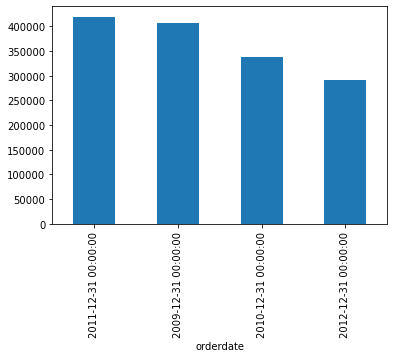

```python
year=df.resample('Y')['profit'].sum().sort_values(ascending=False)[:-1].plot(kind='bar')
```

# Drill Down: What happend in 2009 & January 2009?

## Let's focus on Year 2009 and answer some questions below

### Which region performed so poorly?

```python
d2009=df.loc['2009']
d2009.head()
```

| orderdate | orderid | orderpriority | orderquantity | sales | discount | shipmode | profit | unitprice | shippingcost | customername | customerstate | zipcode | region | customersegment | productcategory | productsub-category | productname | productcontainer | productbasemargin | shipdate |
| --- | --- | --- | --- | --- | --- | --- | --- | --- | --- | --- | --- | --- | --- | --- | --- | --- | --- | --- | --- | --- |
| 2009-04-16 | 69 | Not Specified | 42 | 1186.0600 | 0.09 | Regular Air | 511.690 | 30.93 | 3.92 | Jonathan Doherty | Ohio | 43567 | Central | Corporate | Furniture | Office Furnishings | Advantus Employee of the Month Certificate Fra... | Small Pack | 0.44 | 2009-04-18 |
| 2009-04-16 | 69 | Not Specified | 28 | 51.5300 | 0.03 | Express Air | 0.350 | 1.68 | 0.70 | Jonathan Doherty | Ohio | 43567 | Central | Corporate | Office Supplies | Pens & Art Supplies | Newell 308 | Wrap Bag | 0.60 | 2009-04-18 |
| 2009-02-27 | 96 | High | 37 | 4158.1235 | 0.01 | Regular Air | 1228.887 | 125.99 | 8.99 | Keith Dawkins | Texas | 73301 | Central | Home Office | Technology | Telephones and Communication | SC7868i | Small Box | 0.55 | 2009-03-01 |
| 2009-12-11 | 97 | Medium | 26 | 75.5700 | 0.03 | Regular Air | 28.240 | 2.89 | 0.50 | Craig Yedwab | Arizona | 85354 | West | Consumer | Office Supplies | Labels | Avery 498 | Small Box | 0.38 | 2009-12-12 |
| 2009-04-30 | 224 | Not Specified | 25 | 184.8600 | 0.09 | Regular Air | -33.950 | 7.38 | 5.21 | Bart Folk | Connecticut | 6439 | East | Corporate | Furniture | Office Furnishings | Eldon® Expressions™ Wood Desk Accessories, Oak | Small Box | 0.56 | 2009-05-01 |

```python
d2009.groupby('region')['profit'].sum().sort_values(ascending=False)
```

```
region
South      160088.0775
West       121861.4615
Central     78111.7495
East        46657.2375
Name: profit, dtype: float64
```

- The East perfomed poorly out of all the regions in 2009.

### Which zipcode areas performed so poorly?

```python
d2009.groupby('zipcode')['profit'].sum().sort_values(ascending=True).head()
```

```
zipcode
10501   -16557.0850
35077   -11928.9000
93456   -11522.6075
8989     -7748.9515
49877    -7703.7515
Name: profit, dtype: float64
```

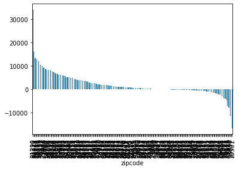

```python
d2009.groupby('zipcode')['profit'].sum().sort_values(ascending=False).plot(kind='bar')
```

- The bar graph above shows the overall perfomance in terms of zipcode in 2009.

### Which product category performed so poorly?

```python
d2009.groupby('productcategory')['profit'].sum().sort_values(ascending=True)
```

```
productcategory
Furniture           71904.900
Office Supplies    167174.061
Technology         167639.565
Name: profit, dtype: float64
```

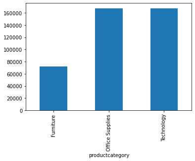

```python
d2009.groupby('productcategory')['profit'].sum().sort_values(ascending=True).plot(kind='bar')
```

- Furniture was the worse overall performing product category in 2009.

### Which productsub-category performed so poorly?

```python
d2009.groupby('productsub-category')['profit'].sum().sort_values(ascending=False)
```

```
productsub-category
Binders and Binder Accessories    109436.821
Telephones and Communication       81614.967
Chairs & Chairmats                 54335.650
Copiers and Fax                    49296.048
Office Furnishings                 25795.640
Computer Peripherals               18595.350
Appliances                         18495.330
Office Machines                    18133.200
Paper                              16214.710
Storage & Organization             14197.810
Envelopes                           7046.170
Labels                              2936.880
Bookcases                           2394.950
Pens & Art Supplies                 1746.230
Rubber Bands                          27.820
Scissors, Rulers and Trimmers      -2927.710
Tables                            -10621.340
Name: profit, dtype: float64
```

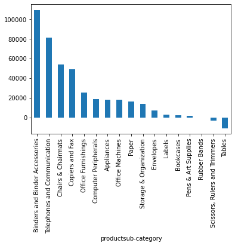

```python
d2009.groupby('productsub-category')['profit'].sum().sort_values(ascending=False).plot(kind='bar')
```

- The ba graph above shows that product sub-category: Tables, Scissors, Rulers and Trimers performed poorly in terms of profit in 2009.

```python
d2009.groupby('productsub-category')['sales'].sum().sort_values(ascending=False)
```

```
productsub-category
Office Machines                   595848.910
Chairs & Chairmats                492855.750
Telephones and Communication      467231.791
Tables                            443875.096
Binders and Binder Accessories    327280.380
Storage & Organization            318305.210
Copiers and Fax                   317123.330
Bookcases                         226657.260
Computer Peripherals              203511.070
Office Furnishings                177617.260
Appliances                        157640.070
Paper                             120688.030
Pens & Art Supplies                39460.140
Envelopes                          31183.570
Scissors, Rulers and Trimmers      17067.110
Labels                              8970.850
Rubber Bands                        2554.310
Name: sales, dtype: float64
```

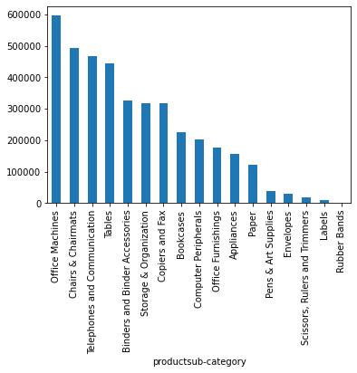

```python
d2009.groupby('productsub-category')['sales'].sum().sort_values(ascending=False).plot(kind='bar')
```

- The bar graph above shows that product sub-category: Rubber Bands performed poorly in terms of sales in 2009.

### Which product performed so poorly?

```python
d2009.groupby('productname')['profit'].sum().sort_values(ascending=True).head(1)
```

```
productname
Okidata Pacemark 4410N Wide Format Dot Matrix Printer   -26610.81
Name: profit, dtype: float64
```

- The product name: Okidata Pacemark 4410N Wide Format Dot Matrix Printer performed poorly in terms of profit in 2009.

```python
d2009.groupby('productname')['sales'].sum().sort_values(ascending=True).head(1)
```

```
productname
*Staples* Packaging Labels    6.13
Name: sales, dtype: float64
```

- The product name: *Staples* Packaging Labels performed poorly in terms of sales in 2009.

## Let's focus on January 2009 and answer some questions below

### Which region performed so poorly?

```python
d2009jan = df.loc['1/1/2009':'1/31/2009']
d2009jan.groupby('region')['profit'].sum().sort_values(ascending=False)
```

```
region
West        3374.3950
Central     2516.9330
South       -463.1045
East      -12084.3320
Name: profit, dtype: float64
```

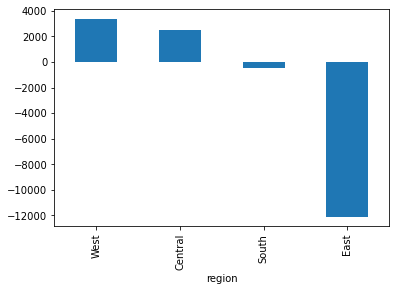

```python
d2009jan.groupby('region')['profit'].sum().sort_values(ascending=False).plot(kind='bar')
```

- Both the table and bar graph show the region perfomance in january 2009 in terms of profit. the south and east reported a loss.

```python
d2009jan.groupby('region')['sales'].sum().sort_values(ascending=False)
```

```
region
South      110149.4795
East        92038.6130
West        56051.6735
Central     37041.4990
Name: sales, dtype: float64
```

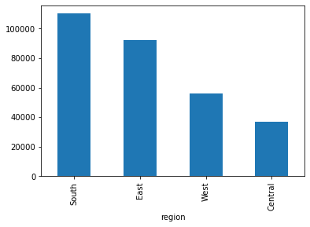

```python
d2009jan.groupby('region')['sales'].sum().sort_values(ascending=False).plot(kind='bar')
```

- Both the table and bar graph above show the region perfomance in january 2009 in terms of sales. The south and east have the highest sales which is weird because they are also experiencing a loss in profit.

### Which zipcode areas performed so poorly?

```python
d2009jan.groupby('zipcode')['profit'].sum().sort_values(ascending=True).head()
```

```
zipcode
10501   -16253.680
35077   -11769.170
21230    -2073.898
5544     -2041.280
23111    -1271.710
Name: profit, dtype: float64
```

- Table above shows zipcode areas that performed so poorly in Jan 2009 in terms of profit. zipcode:10501 is the worst.

```python
d2009jan.groupby('zipcode')['sales'].sum().sort_values(ascending=True).head()
```

```
zipcode
21290     29.23
21022     31.36
80746     82.21
14925     93.73
83810    118.51
Name: sales, dtype: float64
```

- Table above shows zipcode areas that performed so poorly in Jan 2009 in terms of sales. zipcode:21290 is the worst.

### Which product category performed so poorly?

```python
d2009jan.groupby('productcategory')['profit'].sum().sort_values(ascending=True).head()
```

```
productcategory
Technology        -10547.7010
Office Supplies    -1516.0075
Furniture           5407.6000
Name: profit, dtype: float64
```

- The table above shows that product category: Technology and office supplies performed poorly in terms of profit.

```python
d2009jan.groupby('productcategory')['sales'].sum().sort_values(ascending=True).head()
```

```
productcategory
Office Supplies     56731.790
Furniture          119225.416
Technology         119324.059
Name: sales, dtype: float64
```

- The table above shows that product category: Office Supplies performed poorly in terms of sales.

### Which productsub-category performed so poorly?

```python
d2009jan.groupby('productsub-category')['profit'].sum().sort_values(ascending=True).head(7)
```

```
productsub-category
Copiers and Fax                 -8496.27
Office Machines                 -2435.86
Storage & Organization          -2093.51
Tables                          -2010.32
Scissors, Rulers and Trimmers   -1767.60
Bookcases                       -1196.03
Pens & Art Supplies                -3.21
Name: profit, dtype: float64
```

- The above table shows all the poorly performing product sub-category in terms of profit. product sub-category: Copiers and Fax is the most poor performing of all of them.

```python
d2009jan.groupby('productsub-category')['sales'].sum().sort_values(ascending=True).head(7)
```

```
productsub-category
Labels                              444.57
Envelopes                          1247.72
Pens & Art Supplies                2446.02
Binders and Binder Accessories     5200.74
Paper                              5561.16
Scissors, Rulers and Trimmers      9631.78
Office Furnishings                13760.32
Name: sales, dtype: float64
```

- The above table shows the performance of product sub-category in terms of sales. product sub-category: Labels is the poor performing of all of them.

### Which product performed so poorly?

```python
d2009jan.groupby('productname')['profit'].sum().sort_values(ascending=True).head(1)
```

```
productname
Polycom ViewStation™ ISDN Videoconferencing Unit   -16253.68
Name: profit, dtype: float64
```

- The product name: Polycom ViewStation™ ISDN Videoconferencing Unit performed poorly in terms of profit.

```python
d2009jan.groupby('productname')['sales'].sum().sort_values(ascending=True).head(1)
```

```
productname
Newell 343    3.77
Name: sales, dtype: float64
```

- The product name: Newell performed poorly in terms of sales.

# Your Own Questions

```python
# Q1 which state in the west is most profitable in product category?
weststates = df.loc[df['region'] == 'West']
weststates.pivot_table(index="customerstate", columns="productcategory", values="profit", \
               aggfunc='sum', fill_value=0, margins=True)
```

| productcategory customerstate | Furniture | Office Supplies | Technology | All |
| --- | --- | --- | --- | --- |
| Arizona | 3611.15 | 7282.9630 | 49567.281 | 60461.3940 |
| California | 13792.46 | 29394.0675 | 21987.698 | 65174.2255 |
| Colorado | 5253.71 | 21477.1575 | 46844.225 | 73575.0925 |
| Idaho | 10535.04 | 34028.3840 | 34866.825 | 79430.2490 |
| New Mexico | 6139.93 | 9170.8750 | 20075.526 | 35386.3310 |
| Utah | 3054.18 | 29536.3950 | 34355.836 | 66946.4110 |
| Washington | 15298.20 | 14779.6175 | 11816.630 | 41894.4475 |
| All | 57684.67 | 145669.4595 | 219514.021 | 422868.1505 |

- The table above shows that Idaho is best performing state in terms of profit in the product category.

```python
# Q2 what is the most profitable year in Idaho?
idaho = df.loc[df['customerstate'] == 'Idaho']
idahoyear=idaho.resample('Y')['profit'].sum().sort_values(ascending=False)
idahoyear.head()
```

```
orderdate
2011-12-31    35479.0070
2008-12-31    15273.7520
2009-12-31    11837.8540
2010-12-31    11579.3785
2012-12-31     5260.2575
Name: profit, dtype: float64
```

- The table above shows that 2011 was the most profitable year for Idaho.

```python
# Q3 What are the top 2 least profitable(or have losses) product names in Idaho?
idaho.groupby('productname')['profit'].sum().sort_values(ascending=True).head(2)
```

```
productname
Polycom ViewStation™ ISDN Videoconferencing Unit   -11797.31
Canon PC1060 Personal Laser Copier                  -2297.48
Name: profit, dtype: float64
```

- The table above shows that product names: Polycom ViewStation™ ISDN Videoconferencing Unit and Canon PC1060 Personal Laser Copier are the least profitable(they have a loss) in Idaho.

# Your storytelling below

- Use bulleted points and/or numbers
- Treat "your storytelling below" as an executive summary. You can share a few takeaways from your overall analysis. How is the company doing overall? What areas need special attention?
- Increase the number of sales in May.
- Increase the number of profit in June(needs to be in 6 figures like the rest of the months).
- Increase the sales and profit in the furniture product category.
- Technology is the overall best performing product category in terms of sales and profit.
- The South is the best profitable region while Central is the worst.
- The East region has an overall loss in the furniture product category.
- Product sub-category: Book cases, Tables, Rubber bands, Scissors, Rulers and Trimmers are experienceing an overall loss. These sub-categories need special attention.